# Git, GitHub & Ocean Acidification Task #10

Yusheng_Wang_u7457423

2022-09-08

# **Task 10**

This is a stretch task on the use of *GitHub* and the challenges (or maybe lack of challenges) of reproducing others’ work. If you finish the above tasks, then, have a crack at this one. See the html for details.

> **Question 9**: Think about some things that can be improved in their code. List 3 things you think could be improved and provide a brief explanation for why.
1. They only commented what they would do in the following several codes, rather than commenting each code line. They could make more detailed comments to explain what each function and argument do. In this way readers can easier to understand how their codes work.
2. They did not specify clearly which piese of code is used to analyse which content, table or figure in their paper. They could make more comments to show the relation of paper content and codes. In this way readers can review and reproduce their work better.
3. They used lots of functions from base R, rather than packages like tidyverse. They could re-write their codes with these advanced and commonly used packages to simplify their codes. In this way readers can get more familiar their codes and have a better understand.

> **reproduce Fig. 4**:

```r
# Load packages
library(pacman)
p_load(tidyverse, ggplot2, patchwork, Hmisc, png, magick)
```

```r
# Load the data
data_raw <- read_csv("./data/OA_activitydat_20190302_BIOL3207.csv")
```

```
## ──────────────────────────────────────────────────────── Delimiter: "," chr
## (5): loc, species, treatment, size, comment dbl (4): ...1, animal_id, sl,
## activity
```

```r
# Separate the loc column
data_sep <- separate(data_raw, loc, into = c("loc", "year"))
# Filter irrelevant data
data_useful <- data_sep[, c(3, 4, 5, 9)]
# Remove NA
data_useful <- data_useful %>% filter(complete.cases(.))
# Have a quick look
head(data_useful, 10)
```

```
## # A tibble: 10 × 4
##    year  species treatment activity
##    <chr> <chr>   <chr>        <dbl>
##  1 2014  ambon   CO2           8.15
##  2 2014  ambon   CO2          10.5
##  3 2014  ambon   CO2           6.51
##  4 2014  ambon   CO2          27.8
##  5 2014  lemon   CO2          36.7
##  6 2014  ambon   CO2          42.8
##  7 2014  lemon   CO2          21.9
##  8 2014  ambon   CO2          24.6
##  9 2014  ambon   CO2          35.1
## 10 2014  ambon   CO2           1.02
```

```r
# Set time of loop
n_rep <- length(levels(as.factor(data_useful$species)))
# Set a list to store data
data_species <- list(1, 2, 3, 4, 5, 6)
# Filter data by species
for (i in 1 : n_rep) {
  data_species[[i]] <- data_useful %>% filter(species == levels(as.factor(data_useful$species))[i])

  # Change the level of treatment
  data_species[[i]]$treatment <- factor(data_species[[i]]$treatment, levels = rev(levels(as.factor((data_species[[i]]$treatment)))))
}
# Have a look
data_species
```

```
## [[1]]
## # A tibble: 194 × 4
##    year  species treatment activity
##    <chr> <chr>   <fct>        <dbl>
##  1 2014  acantho CO2           3.66
##  2 2014  acantho CO2          28.9
##  3 2014  acantho CO2          10.8
##  4 2014  acantho CO2          14.1
##  5 2014  acantho CO2          12.0
##  6 2014  acantho CO2           8.07
##  7 2014  acantho CO2          30.4
##  8 2014  acantho CO2          39.9
##  9 2014  acantho control       1.97
## 10 2014  acantho control       7.00
## # … with 184 more rows
## # ℹ Use `print(n = ...)` to see more rows
##
## [[2]]
## # A tibble: 43 × 4
##    year  species treatment activity
##    <chr> <chr>   <fct>        <dbl>
##  1 2014  ambon   CO2           8.15
##  2 2014  ambon   CO2          10.5
##  3 2014  ambon   CO2           6.51
##  4 2014  ambon   CO2          27.8
##  5 2014  ambon   CO2          42.8
##  6 2014  ambon   CO2          24.6
##  7 2014  ambon   CO2          35.1
##  8 2014  ambon   CO2           1.02
##  9 2014  ambon   CO2           9.11
## 10 2014  ambon   CO2          10.9
## # … with 33 more rows
## # ℹ Use `print(n = ...)` to see more rows
##
## [[3]]
## # A tibble: 34 × 4
##    year  species treatment activity
##    <chr> <chr>   <fct>        <dbl>
##  1 2014  chromis CO2           14.9
##  2 2014  chromis CO2           21.2
```

[output cut: 46 more lines]

```
## # A tibble: 122 × 4
##    year  species   treatment activity
##    <chr> <chr>     <fct>        <dbl>
##  1 2016  whitedams CO2           31.3
##  2 2016  whitedams control       31.5
##  3 2016  whitedams CO2           11.1
##  4 2016  whitedams CO2           31.4
##  5 2016  whitedams CO2           36.2
##  6 2016  whitedams CO2           20.5
##  7 2016  whitedams CO2           21.2
##  8 2016  whitedams CO2           17.7
##  9 2016  whitedams CO2           19.7
## 10 2016  whitedams CO2           21.6
## # … with 112 more rows
## # ℹ Use `print(n = ...)` to see more rows
```

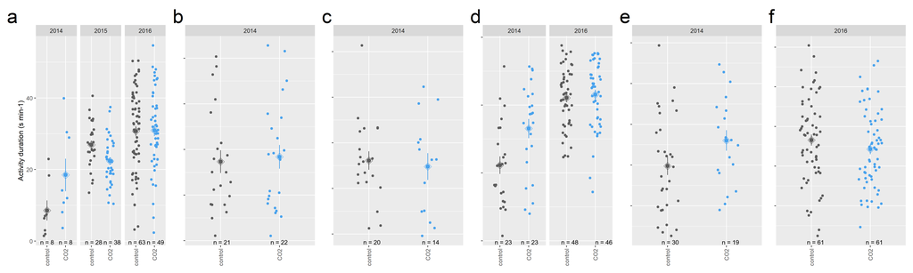

```r
# Set a list to store plots
list_plot <- list(1, 2, 3, 4, 5, 6)
# Make the first plot
pl <- ggplot(data_species[[1]], aes(x = treatment, y = activity, color = treatment)) +
  stat_summary(fun.y = mean, geom = "point", shape = 23, size=4) +
  geom_jitter(width = 0.2, ) +
  stat_summary(fun.data = mean_se) +
  labs(y = "Activity duration (s min-1)") +
  facet_grid(~ year, margins = c("n = 1", "n=2")) +
  theme(legend.position = 'none', axis.title.x=element_blank(), axis.text.x=element_blank()) +
  theme(axis.text.x = element_text(angle = 90, hjust = 1, vjust = .5)) +
  scale_color_manual(values = c("#5b5b5b", "#48a2ed"))
list_plot[[1]] <- pl
# Make the matrix plot
for (i in 2 : n_rep) {
  pl <- ggplot(data_species[[i]], aes(x = treatment, y = activity, color = treatment)) +
    stat_summary(fun.y = mean, geom = "point", shape = 23, size=4) +
    geom_jitter(width = 0.2) +
    stat_summary(fun.data = mean_se) +
    facet_grid(~ year) +
    theme(legend.position = 'none', axis.title.y=element_blank(), axis.text.y=element_blank(), axis.title.x=element_blank(), axis.text.x=element_blank()) +
    theme(axis.text.x = element_text(angle = 90, hjust = 1, vjust = .5)) +
    scale_color_manual(values = c("#5b5b5b", "#48a2ed"))
  list_plot[[i]] <- pl
}
pall <- list_plot[[1]] + list_plot[[2]] + list_plot[[3]] + list_plot[[4]] + list_plot[[5]] + list_plot[[6]] + plot_layout(nrow = 1) +
  plot_annotation(tag_levels = 'a') & theme(plot.tag = element_text(size = 30))

ggsave('./output/figures/activity.png', width = 500, height = 150, units = "mm")

# Add simple size for each plot
Fig10 <- image_read('./output/figures/activity.png') %>%
  image_annotate(., text = "n = 8", location = "+260+1550", size = 40, color = "black") %>%
  image_annotate(., text = "n = 8", location = "+380+1550", size = 40, color = "black") %>%
  image_annotate(., text = "n = 28", location = "+550+1550", size = 40, color = "black") %>%
  image_annotate(., text = "n = 38", location = "+670+1550", size = 40, color = "black") %>%
  image_annotate(., text = "n = 63", location = "+830+1550", size = 40, color = "black") %>%
  image_annotate(., text = "n = 49", location = "+950+1550", size = 40, color = "black") %>%
  image_annotate(., text = "n = 21", location = "+1380+1550", size = 40, color = "black") %>%
  image_annotate(., text = "n = 22", location = "+1750+1550", size = 40, color = "black") %>%
  image_annotate(., text = "n = 20", location = "+2350+1550", size = 40, color = "black") %>%
  image_annotate(., text = "n = 14", location = "+2730+1550", size = 40, color = "black") %>%
  image_annotate(., text = "n = 23", location = "+3200+1550", size = 40, color = "black") %>%
  image_annotate(., text = "n = 23", location = "+3370+1550", size = 40, color = "black") %>%
  image_annotate(., text = "n = 48", location = "+3630+1550", size = 40, color = "black") %>%
  image_annotate(., text = "n = 46", location = "+3850+1550", size = 40, color = "black") %>%
  image_annotate(., text = "n = 30", location = "+4280+1550", size = 40, color = "black") %>%
  image_annotate(., text = "n = 19", location = "+4670+1550", size = 40, color = "black") %>%
  image_annotate(., text = "n = 61", location = "+5220+1550", size = 40, color = "black") %>%
  image_annotate(., text = "n = 61", location = "+5600+1550", size = 40, color = "black")

# Output the final figure
  image_write(Fig10, path = './output/figures/activity.png', format = "png")

Fig10
```

> **Question 10**: What are the challenges, if any, that you encounter in reproducing this figure?

# Describe challenges

1. Even though I made a similar image (with same information), I think I used the most complicated method (some hard codes). It is because I do not learn enough about R.
2. Because of the different functions I used from the authors, some aesthetic pattern cannot be completely reproduced.